# Bright Horizons

**Navigating Youth Challenges in the Middle East & North Africa (MENA)**

Author

Faisal Bouran

Published

April 27, 2025

[figure not shown]

```python
img1 = mpimg.imread('/content/unicef')
img2 = mpimg.imread('/content/pngwing.com (2).png')
fig, axs = plt.subplots(1, 2, figsize=(5, 2))

axs[0].imshow(img1)
axs[0].axis('off')

axs[1].imshow(img2)
axs[1].axis('off')

plt.tight_layout()
plt.show()
```

# The Middle East and North Africa (MENA) is a region of contrasts

It is home to a culturally diverse group of low, middle, and high income countries. There are around **185 million young people** under the age of 18 living in **22 Arab MENA countries**, representing **38 per cent** of the regional population.

- Conflict and political instability.
- Displacement from one country to another.
- Social factors such creating gender disparities in education between male and female youth.

The chart below suggests that with rising levels of youth under the age of 18, life expectancy has improved positively since the 1980’s due to imporved education levels at an eary age, resulting in youth being more engaged in industries. The focus on **female involvement in the workplace**, has also reduced **gender disparities** in some countries.

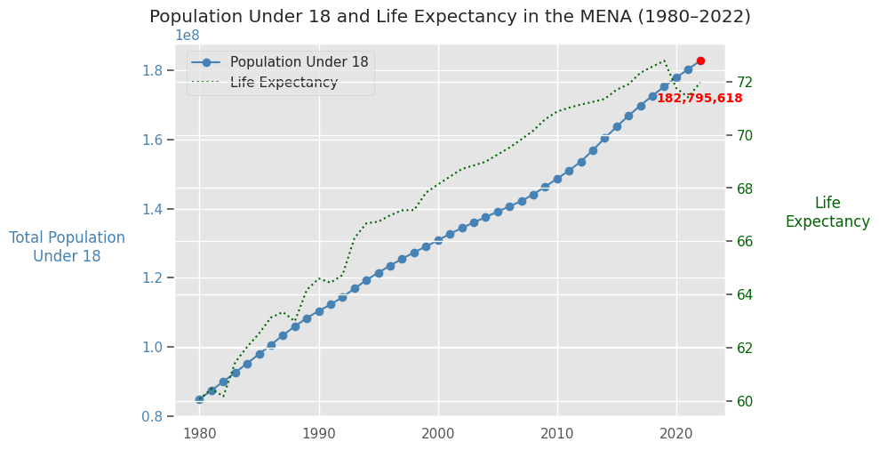

```python
df = (
    menadata
    .filter((pl.col("year") >= 1980) & (pl.col("year") <= 2022))
    .to_pandas()
)
df_grouped = df.groupby("year", as_index=False).agg(
    total_population_under18=('total_population_under18', 'sum'),
    life_expectancy=('life_expectancy', 'mean')
)
max_row = df_grouped.loc[df_grouped["total_population_under18"].idxmax()]
fig, ax1 = plt.subplots(figsize=(10, 5))

pop_line, = ax1.plot(df_grouped["year"], df_grouped["total_population_under18"],
                     marker="o", color="steelblue", label="Population Under 18")
ax1.set_ylabel("Total Population\nUnder 18", color="steelblue", rotation=0, labelpad=60, va='top')
ax1.tick_params(axis='y', labelcolor="steelblue")
ax1.scatter(max_row["year"], max_row["total_population_under18"], color="red", zorder=5)
ax1.text(
    max_row["year"],
    max_row["total_population_under18"] - 0.05 * df_grouped["total_population_under18"].max(),
    f'{int(max_row["total_population_under18"]):,}',
    ha='center', va='top', fontsize=10, weight='bold', color='red'
)

ax2 = ax1.twinx()
life_line, = ax2.plot(df_grouped["year"], df_grouped["life_expectancy"],
                      linestyle=":", color="darkgreen", label="Life Expectancy")
ax2.set_ylabel("Life\nExpectancy", color="darkgreen", rotation=0, labelpad=60, va='bottom')
ax2.tick_params(axis='y', labelcolor="darkgreen")

lines = [pop_line, life_line]
labels = [line.get_label() for line in lines]
ax1.legend(lines, labels, loc='upper left', bbox_to_anchor=(0.01, 1), frameon=True)

plt.title("Population Under 18 and Life Expectancy in the MENA (1980–2022)")
plt.grid(True)
fig.tight_layout()
plt.show()
```

Several factors cause the life expectancy line to fluctuate across the different geopolitical circumistances of the MENA. A sharp decrease is noticable in the 2020’s indicating events taking place such as **COVID 19, forced displacement, and conflict among societies**.

# Comparitive Analysis on the Region through the United Nations Sustainable Development Goals (UN SDGs)

[figure not shown]

```python
img1 = mpimg.imread('/content/SDG4.png')
img2 = mpimg.imread('/content/SDG9.png')
img3 = mpimg.imread('/content/SDG10.png')

fig, axs = plt.subplots(1, 3, figsize=(5, 2))

axs[0].imshow(img1)
axs[0].axis('off')

axs[1].imshow(img2)
axs[1].axis('off')

axs[2].imshow(img3)
axs[2].axis('off')

plt.tight_layout()
plt.show()
```

#### Steady Progress in the Education and Living Standards

Countries like **Bahrain** in the Arabian Gulf and **Tunisia** in North Africa are among the top performers in the region, with significant advancements in SDGs. **Quality Education (SDG 4)** and **Industry, Innovation, and Infrastructure (SDG 9)**, **Health and Well Being (SDG 3)** and **Reduced Inequalities (SDG 10)**. It is generally a healthy sign of a country’s outlook with a steady growth in life expectancy, demonstrating improving living standards and at every generation.

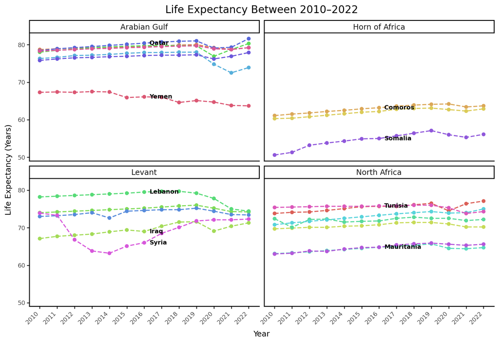

```python
import pandas as pd
from plotnine import *
mena_data = pd.read_csv('/content/MENA_Data.csv')
filtered_pd = mena_data[(mena_data['year'] >= 2010) & (mena_data['year'] <= 2022)].copy()
filtered_pd['year'] = filtered_pd['year'].astype(int)

countries_to_label = ["Qatar", "Yemen", "Comoros", "Somalia", "Lebanon", "Iraq", "Syria", "Tunisia", "Mauritania"]
middle_year = 2016

label_rows = []

for region, group_region in filtered_pd.groupby('region'):
    for country, group_country in group_region.groupby('country'):
        if country in countries_to_label:
            group_country['year_diff'] = (group_country['year'] - middle_year).abs()
            middle_point = group_country.sort_values('year_diff').iloc[0]
            label_rows.append(middle_point)

label_data = pd.DataFrame(label_rows)

(
    ggplot(filtered_pd)
    + aes(x="year", y="life_expectancy", group="country", color="country")
    + geom_line(linetype='dashed', size=0.7)
    + geom_point(size=1.5)
    + geom_text(
        data=label_data,
        mapping=aes(x="year", y="life_expectancy", label="country"),
        size=7,
        fontweight='bold',
        ha='left',
        nudge_x=0.3,
        color='black',
        show_legend=False
    )
    + facet_wrap('region', ncol=2)
    + theme_classic()
    + theme(
        figure_size=(8, 5.5),
        axis_text_x=element_text(angle=45, hjust=1, size=7),
        axis_text_y=element_text(size=7),
        axis_title_x=element_text(size=9),
        axis_title_y=element_text(size=9),
        plot_title=element_text(size=12, ha='center'),
        legend_position='none',
        text=element_text(family="DejaVu Sans")
    )
    + labs(
        x="Year",
        y="Life Expectancy (Years)",
        title="Life Expectancy Between 2010–2022"
    )
    + scale_x_continuous(breaks=range(2010, 2023))
)
```

#### Political Instability Has a Direct Impact on Relatively Younger Populations**

The ongoing conflicts in specifically in individual countries of each region has severely hindered progress across multiple SDGs: **Poverty (SDG 1)**, **Hunger (SDG 2)**, and **Health (SDG 3)**. Due to political and economic instability, some countries like Sudan are off track to meet some SDGs such as **Decent Work and Economic growth (SDG 8)** and **Peace, Justice, and Strong Institutions (SDG 16)**. As shown on the regional life expectancy analysis, some countries, like **Yemen** and **Somalia** stand out from their neighbours in the same proximity due to sharp social and political conditions impacting their communities, demonstrating up to **20%** difference in life expectancy and living standards. For example, during the years of 2011 and 2014, we can observe the **contiuous decline in life expectany in Syria** as a result of the **Syrian civil war**, which started in 2011 and was at its peak in 2014.

[figure not shown]

```python
img1 = mpimg.imread('/content/SDG1.png')
img2 = mpimg.imread('/content/SDG3.png')
img3 = mpimg.imread('/content/SDG5.png')

fig, axs = plt.subplots(1, 3, figsize=(5, 2))

axs[0].imshow(img1)
axs[0].axis('off')

axs[1].imshow(img2)
axs[1].axis('off')

axs[2].imshow(img3)
axs[2].axis('off')

plt.tight_layout()
plt.show()
```

**Civil War in Syria**

Over one-third of Syrian children are out of school, with 2.4 million children aged 5-17 not attending classes, and the majority being displaced internally and externally. This exposes them to risks such as child labor, early marriage, and recruitment into armed groups. Moreover, many of the youth population had joined armed groups in the conflict and did not recieve education.

# The Human Capital Index: *Insights on How Literacy Rate Impacts Life Expectancy for Youth Populations*

**The Human Capital Index (HCI)**

An index to capture the amount of human capital a child born today could attain by the age of 18, given the risks of poor health and lack of education that prevail in the country where they live.

The HCI evaluates how well countries prepare their populations for productive work, it measures factors within the living conditions of youth groups, such as early level education and access to healthcare, that determine how they would contribute to their communities as adults.

*The chart below examines the status of each MENA country according to their index catagory*

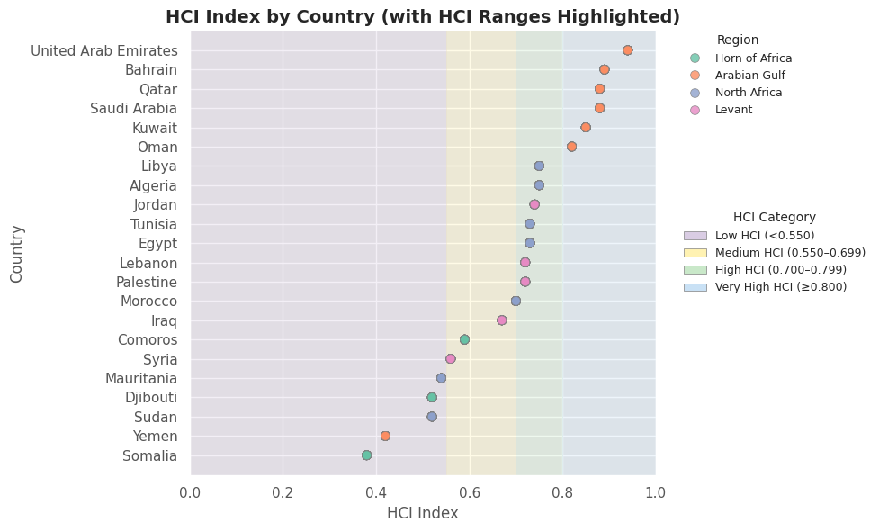

```python
mena_data = pd.read_csv('/content/MENA_Data.csv')

df_plot = mena_data[['country', 'region', 'HCIindex']].dropna()
df_plot = df_plot.sort_values(by='HCIindex')

# Set up the plot
plt.figure(figsize=(10, 6))  # Nice size for HTML

# Create the background colored bands (but no legend from these directly)
plt.axvspan(0, 0.55, color='#d9cce3', alpha=0.3)
plt.axvspan(0.55, 0.70, color='#fff2b2', alpha=0.3)
plt.axvspan(0.70, 0.80, color='#c9e8c9', alpha=0.3)
plt.axvspan(0.80, 1.0, color='#c9e1f5', alpha=0.3)

# Plot points
scatter = sns.scatterplot(
    data=df_plot,
    x='HCIindex',
    y='country',
    hue='region',
    palette='Set2',
    s=50,
    edgecolor='gray',
    alpha=0.8
)

plt.gca().invert_yaxis()
plt.xlabel('HCI Index')
plt.ylabel('Country')
plt.title('HCI Index by Country (with HCI Ranges Highlighted)', fontsize=14, weight='bold')
plt.xlim(0, 1)

hci_legend_patches = [
    Patch(facecolor='#d9cce3', edgecolor='gray', label='Low HCI (<0.550)'),
    Patch(facecolor='#fff2b2', edgecolor='gray', label='Medium HCI (0.550–0.699)'),
    Patch(facecolor='#c9e8c9', edgecolor='gray', label='High HCI (0.700–0.799)'),
    Patch(facecolor='#c9e1f5', edgecolor='gray', label='Very High HCI (≥0.800)')
]

region_legend = plt.legend(
    title='Region',
    bbox_to_anchor=(1.05, 1),
    loc='upper left',
    borderaxespad=0.,
    fontsize=9,
    title_fontsize=10,
    frameon=False
)

plt.gca().add_artist(region_legend)
plt.legend(
    handles=hci_legend_patches,
    title='HCI Category',
    bbox_to_anchor=(1.05, 0.5),
    loc='center left',
    borderaxespad=0.,
    fontsize=9,
    title_fontsize=10,
    frameon=False
)

plt.tight_layout()

plt.show()
```

*Measures included in the index:*

- **Probability of children surviving to age 5**
- **Expected years of schooling and learning outcomes**
- **Indicates the health conditions of young populations in their countries**

It the HCI chart for the four regions in MENA allows us to identify regional trends in living conditions that impact the development of the populations and future outlook on the youth generations. It is noticable that the Arabian Gulf has the highest HCI of 0.8, but if we consider Yemen, which belongs to the same region, has poorer conditions impacting their youth due to the on going war and conflict.

**The War in Yemen**

Since the conflict in 2015, more than 11,000 children have been killed or injured, averaging four children per day. Widespread poverty forced many families to prioritize immediate economic needs over education, leading to higher dropout rates among girls.

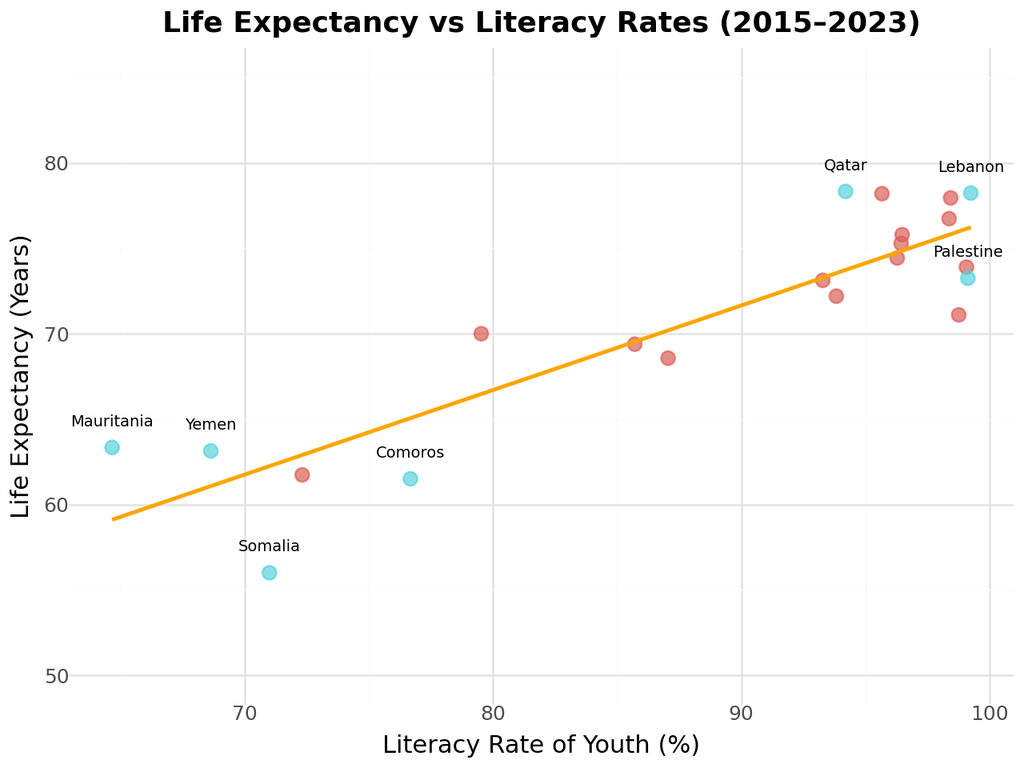

```python
df = pd.read_csv('/content/MENA_Data.csv')


df_plot = (
    df[['country', 'Literacy_rate_total', 'life_expectancy']]
    .dropna()
    .groupby('country', as_index=False)
    .mean()
)

df_plot['highlight_label'] = ""


top_literacy = df_plot.nlargest(2, 'Literacy_rate_total')
bottom_literacy = df_plot.nsmallest(2, 'Literacy_rate_total')

top_life = df_plot.nlargest(2, 'life_expectancy')
bottom_life = df_plot.nsmallest(2, 'life_expectancy')

highlight_indices = pd.concat([top_literacy, bottom_literacy, top_life, bottom_life]).index
df_plot.loc[highlight_indices, 'highlight_label'] = df_plot.loc[highlight_indices, 'country']
(
    ggplot(df_plot)
    + aes(x='Literacy_rate_total', y='life_expectancy')
    + geom_point(
        aes(color=(df_plot['highlight_label'] != "")),
        size=3,
        alpha=0.7
    )
    + geom_smooth(method='lm', color="#FFA500", se=False)
    + geom_text(
        aes(label='highlight_label'),
        size=7,
        nudge_y=1.5,
        color='black'
    )
    + scale_y_continuous(limits=(50, 85))
    + labs(
        title="Life Expectancy vs Literacy Rates (2015–2023)",
        x="Literacy Rate of Youth (%)",
        y="Life Expectancy (Years)"
    )
    + theme_minimal()
    + theme(
        plot_title=element_text(size=13, weight="bold", ha='center'),
        axis_title_x=element_text(size=11),
        axis_title_y=element_text(size=11),
        axis_text=element_text(size=9),
        legend_position='none'
    )
)
```

The analysis indicate that poor social and economic conditions cause a young population to sustain a lower life expectancy. On the otherhand, countries such as Palestine and Lebanon, falling at the High HCI catagories, host the highest literacy rates as opposed to countries in the Very High HCI catagory, such as Qatar, which in return have a higher life expectancy out of all the region.

# Gender Disparities and Impact on Economic and Social Markers

Regions that experienced war and conflict in the last 15 years tend to have higher percentage of under 18 population. In some parts playing in to reducing GDP per capital growth and an increase in gender inequalities.

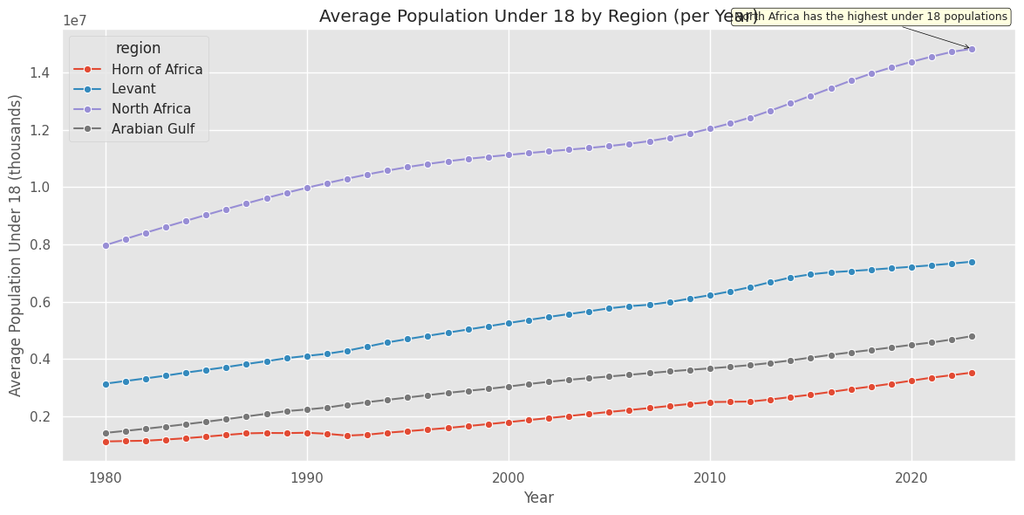

```python
df_grouped = (
    menadata
    .group_by("year", "region")
    .agg(pl.col("total_population_under18").mean().alias("Total Population Under18"))
    .to_pandas()
)

north_africa_latest = df_grouped[df_grouped["region"] == "North Africa"].sort_values("year").iloc[-1]

plt.figure(figsize=(12, 6))
ax = sns.lineplot(
    data=df_grouped,
    x="year",
    y="Total Population Under18",
    hue="region",
    marker="o"
)

ax.annotate(
    "North Africa has the highest under 18 populations",
    xy=(north_africa_latest["year"], north_africa_latest["Total Population Under18"]),
    xytext=(north_africa_latest["year"] - 5, north_africa_latest["Total Population Under18"] + 1e6),
    arrowprops=dict(arrowstyle="->", color="black"),
    bbox=dict(boxstyle="round,pad=0.3", edgecolor="black", facecolor="lightyellow"),
    fontsize=9,
    ha="center"
)

plt.title("Average Population Under 18 by Region (per Year)")
plt.xlabel("Year")
plt.ylabel("Average Population Under 18 (thousands)")
plt.grid(True)
plt.tight_layout()
plt.show()
```

- **A larger gender disparities in education and employment**
- **A larger portion of refugees as a country of origin**
- **A lower GDP per capita over the years**

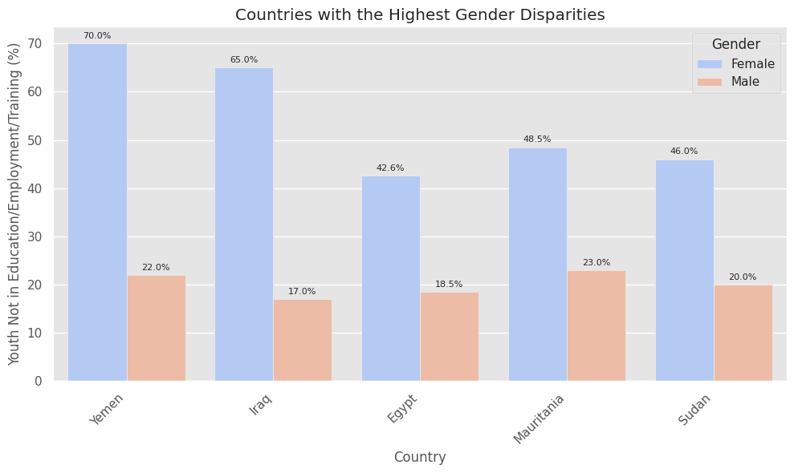

```python
mena_data = pd.read_csv(r"/content/MENA_Data.csv")

filtered_data = mena_data[(mena_data['year'] >= 2009) & (mena_data['year'] <= 2017)]

required_columns = [
    'region',
    'country',
    'Share_of_females_not_in_education_employment_or_training',
    'Share_of_male_not_in_education_employment_or_training'
]
for col in required_columns:
    if col not in filtered_data.columns:
        raise ValueError(f"Ensure '{col}' exists in MENA_Data.csv")

country_grouped = filtered_data.groupby(['region', 'country'], as_index=False)[
    [
        'Share_of_females_not_in_education_employment_or_training',
        'Share_of_male_not_in_education_employment_or_training'
    ]
].mean()

selected_countries = ['Yemen', 'Iraq', 'Egypt', 'Sudan', 'Mauritania']
country_grouped = country_grouped[country_grouped['country'].isin(selected_countries)]

melted_data = country_grouped.melt(
    id_vars=['region', 'country'],
    value_vars=[
        'Share_of_females_not_in_education_employment_or_training',
        'Share_of_male_not_in_education_employment_or_training'
    ],
    var_name='Gender',
    value_name='Share Not in Education/Employment/Training'
)

melted_data['Gender'] = melted_data['Gender'].replace({
    'Share_of_females_not_in_education_employment_or_training': 'Female',
    'Share_of_male_not_in_education_employment_or_training': 'Male'
})

plt.figure(figsize=(10, 6))
barplot = sns.barplot(
    data=melted_data,
    x='country',
    y='Share Not in Education/Employment/Training',
    hue='Gender',
    palette='coolwarm'
)

for container in barplot.containers:
    barplot.bar_label(container, fmt='%.1f%%', padding=3, fontsize=8)

plt.title("Countries with the Highest Gender Disparities")
plt.ylabel("Youth Not in Education/Employment/Training (%)")
plt.xlabel("Country")
plt.legend(title="Gender")
plt.xticks(rotation=45, ha='right')
plt.tight_layout()
plt.show()
```

**Mauritania’s Regional Isolation**

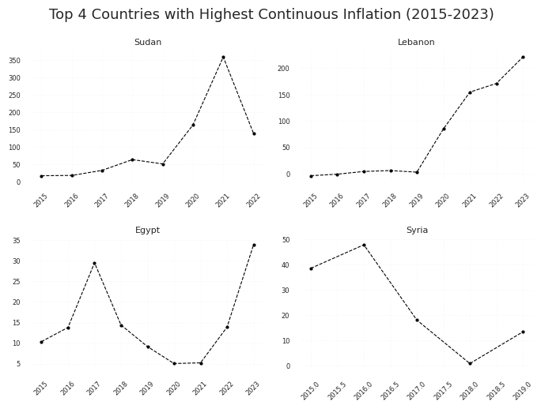

```python
df = pd.read_csv('/content/MENA_Data.csv')

df_filtered = df[(df['year'] >= 2015) & (df['year'] <= 2023)]

if 'Inflation' not in df_filtered.columns:
    raise ValueError("Inflation column not found in the dataset.")

inflation_by_country = df_filtered.groupby(['country', 'year'])['Inflation'].mean().reset_index()


total_inflation = (
    inflation_by_country.groupby('country')['Inflation']
    .sum()
    .sort_values(ascending=False)
    .head(4)
    .reset_index()
)

top_countries = total_inflation['country'].tolist()
inflation_top = inflation_by_country[inflation_by_country['country'].isin(top_countries)]

sns.set_theme(style="white")

n_cols = 2
n_rows = -(-len(top_countries) // n_cols)

fig, axes = plt.subplots(n_rows, n_cols, figsize=(7, 2.5 * n_rows))

fig.suptitle('Top 4 Countries with Highest Continuous Inflation (2015-2023)', fontsize=13, fontweight='normal', y=1.03)

axes = axes.flatten()

for idx, country in enumerate(top_countries):
    country_data = inflation_top[inflation_top['country'] == country]

    axes[idx].plot(
        country_data['year'],
        country_data['Inflation'],
        linestyle='--',
        marker='o',
        markersize=2,
        linewidth=0.8,
        color='black'
    )

    axes[idx].set_title(f'{country}', fontsize=8, fontweight='normal')
    axes[idx].set_xlabel('')
    axes[idx].set_ylabel('')
    axes[idx].tick_params(axis='x', rotation=45, labelsize=6)
    axes[idx].tick_params(axis='y', labelsize=6)


    axes[idx].grid(True, linestyle=':', linewidth=0.4, alpha=0.3)


    for spine in axes[idx].spines.values():
        spine.set_visible(False)

for j in range(idx + 1, len(axes)):
    fig.delaxes(axes[j])

plt.tight_layout(pad=1)
plt.subplots_adjust(top=0.92)

plt.savefig('inflation_top_countries_2015_2023_clean.png', dpi=150, transparent=True)

plt.show()
```

**The Conflict in Sudan**

Low female literacy leads to higher maternal mortality as women may lack awareness of prenatal and postnatal care. Many women depend on traditional practices rather than medical professionals.

The analysis indicate that poor social and economic conditions cause a young population to sustain a lower life expectancy

**There is a need to Address Youth Migration and Brain Drain**

By developing programs aimed at involving displaced children and youth in education, community development, and conflict resolution efforts To provide psychosocial support for young people affected by violence or displacement to integrate them into the workforce and society.